# Simulate of Gestational Periods (Binomial), Conception Dates (Mixture), and Temperature Exposures (Sine wave and AR(1)) during Pregnancy

[Fan Wang](https://fanwangecon.github.io/)

2021-09-29

# 1 Conception, Birth and Extreme Temperature

The various simulations on this page are done in support of [Same Environment, Stratified Impacts? Air Pollution, Extreme Temperatures, and Birth Weight in South China](https://papers.ssrn.com/sol3/papers.cfm?abstract_id=3759319).

> Go to the [**RMD**](https://github.com/FanWangEcon//R4Econ/blob/master/statistics/discrandvar//fs_birth_shock.Rmd), [**R**](https://github.com/FanWangEcon//R4Econ/blob/master/statistics/discrandvar//htmlpdfr/fs_birth_shock.R), [**PDF**](https://github.com/FanWangEcon//R4Econ/blob/master/statistics/discrandvar//htmlpdfr/fs_birth_shock.pdf), or [**HTML**](https://fanwangecon.github.io//R4Econ/statistics/discrandvar//htmlpdfr/fs_birth_shock.html) version of this file. Go back to [fan](http://fanwangecon.github.io/)’s [REconTools](https://fanwangecon.github.io/REconTools/) Package, [R Code Examples](https://fanwangecon.github.io/R4Econ/) Repository ([bookdown site](https://fanwangecon.github.io/R4Econ/bookdown)), or [Intro Stats with R](https://fanwangecon.github.io/Stat4Econ/) Repository ([bookdown site](https://fanwangecon.github.io/Stat4Econ/bookdown)).

## 1.1 Gestational Age at Birth Distribution (Binomial)

Suppose the number of weeks that an individual is pregnant follows the binomial distributions. According to data from the [Right from the Start](https://enactwv.org/programs/right-from-the-start/) study from West Virginia, published in [Hoffman et al. (2008)](https://doi.org/10.1111/j.1365-3016.2008.00965.x), median gestational age at birth was $276/7$ weeks and the standard deviation was around $14/7$ weeks. We use [binomial to approximate normal](https://fanwangecon.github.io/R4Econ/statistics/discrandvar/htmlpdfr/fs_disc_approx_cts.html) rules to generate the relevant binomial parameters.

On each date after conception, there is some chance to give birth, due to various purely random factors, denote this chance as $p_{\tau,i}$, where $\tau$ is discrete time since conception, $p_{\tau, i}$ follows the just defined binomial distribution. The distribution might or might not be individual specific. They would be individual-specific if individual experiences during the course of pregnancy, such as exposures to extreme temeprature, matter for gestational age at birth. The probability that an individual $i$ gives birth during the week of conception is $p_{0,i}$. Conditional on proceeding to the day after conception, the probability of giving birth is $\frac{p_{1,i}}{1-p_{0,i}}$. Similarly for future dates. The conditional birth probability is the Hazard rate in this scenario.

Below, we formulate the gestational age at birth distribution function *ffi_gestation_age_at_birth_dist()*.

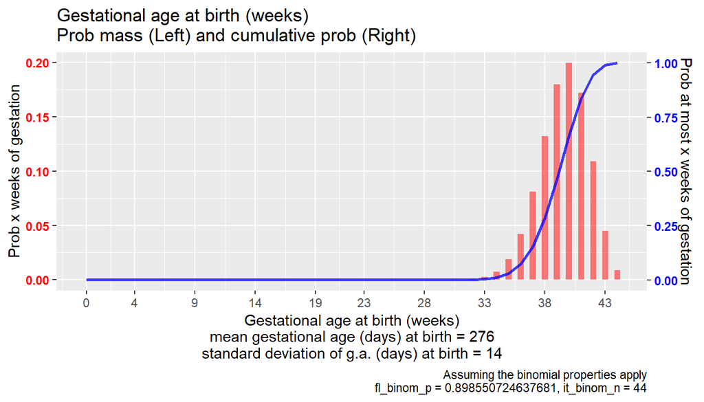

```r
# This function generates the distribution of gestational weeks at birth
ffi_gestation_age_at_birth_dist <- function(
  mu_gabirth_days = 276,
  sd_gabirth_days = 14
){
  # # Parameters
  # # gabirth = gestational age at birth
  # mu_gabirth_days <- 276
  # sd_gabirth_days <- 14
  # from https://fanwangecon.github.io/R4Econ/statistics/discrandvar/htmlpdfr/fs_disc_approx_cts.html
  it_binom_n <- round((mu_gabirth_days / 7)^2 / (mu_gabirth_days / 7 - (sd_gabirth_days / 7)^2))
  fl_binom_p <- 1 - (sd_gabirth_days / 7)^2 / (mu_gabirth_days / 7)

  # Same graphing code as from: https://fanwangecon.github.io/Stat4Econ/probability_discrete/htmlpdfr/binomial.html#24_binomial_example:_wwii_german_soldier
  # Generate Data
  ar_grid_gabirth <- 0:it_binom_n
  ar_pdf_gabirth <- dbinom(ar_grid_gabirth, it_binom_n, fl_binom_p)
  ar_cdf_gabirth <- pbinom(ar_grid_gabirth, it_binom_n, fl_binom_p)
  df_dist_gabirth <- tibble(gabirth = (ar_grid_gabirth), prob = ar_pdf_gabirth, cum_prob = ar_cdf_gabirth)

  # Two axis colors
  axis_sec_ratio <- max(ar_cdf_gabirth) / max(ar_pdf_gabirth)
  right_axis_color <- "blue"
  left_axis_color <- "red"

  # Probabilities
  plt_dist_gabirth <- df_dist_gabirth %>%
    ggplot(aes(x = gabirth)) +
    geom_bar(aes(y = prob),
      stat = "identity", alpha = 0.5, width = 0.5, fill = left_axis_color
    )

  # Cumulative Probabilities
  plt_dist_gabirth <- plt_dist_gabirth +
    geom_line(aes(y = cum_prob / axis_sec_ratio),
      alpha = 0.75, size = 1, color = right_axis_color
    )

  # Titles Strings etc
  graph_title <- paste0("Gestational age at birth (weeks)\n",
      "Prob mass (Left) and cumulative prob (Right)")
  graph_caption <- paste0("Assuming the binomial properties apply\n",
      "fl_binom_p = ", fl_binom_p, ", it_binom_n = ", it_binom_n)
  graph_title_x <- paste0("Gestational age at birth (weeks)\n",
    "mean gestational age (days) at birth = ", mu_gabirth_days, "\n",
    "standard deviation of g.a. (days) at birth = ", sd_gabirth_days)
  graph_title_y_axisleft <- "Prob x weeks of gestation"
  graph_title_y_axisright <- "Prob at most x weeks of gestation"

  # Titles etc
  plt_dist_gabirth <- plt_dist_gabirth +
    labs(
      title = graph_title,
      x = graph_title_x,
      y = graph_title_y_axisleft,
      caption = graph_caption
    ) +
    scale_y_continuous(
      sec.axis =
        sec_axis(~ . * axis_sec_ratio, name = graph_title_y_axisright)
    ) +
    scale_x_continuous(
      labels = ar_grid_gabirth[floor(seq(1, it_binom_n, length.out = 10))],
      breaks = ar_grid_gabirth[floor(seq(1, it_binom_n, length.out = 10))]
    ) +
    theme(
      axis.text.y = element_text(face = "bold"),
      axis.text.y.right = element_text(color = right_axis_color),
      axis.text.y.left = element_text(color = left_axis_color)
    )

  # Print
  return(list(
    df_dist_gabirth=df_dist_gabirth,
    plt_dist_gabirth=plt_dist_gabirth
  ))
}
# Test the function
ls_gsbirth <- ffi_gestation_age_at_birth_dist(mu_gabirth_days = 276, sd_gabirth_days = 14)
# Figure
print(ls_gsbirth$plt_dist_gabirth)
```

```r
# Table
df_dist_gabirth <- ls_gsbirth$df_dist_gabirth
kable(df_dist_gabirth %>% filter(prob >= 0.01)) %>% kable_styling_fc()
```

| gabirth | prob | cum_prob |
| --- | --- | --- |
| 35 | 0.0190913 | 0.0303855 |
| 36 | 0.0422736 | 0.0726591 |
| 37 | 0.0809563 | 0.1536154 |
| 38 | 0.1320866 | 0.2857020 |
| 39 | 0.1799862 | 0.4656882 |
| 40 | 0.1992704 | 0.6649586 |
| 41 | 0.1721918 | 0.8371504 |
| 42 | 0.1089377 | 0.9460881 |
| 43 | 0.0448780 | 0.9909661 |

Some research on the distribution of gestational ages at birth:

- Gage (2002)
- [Nassar et al. (2013)](https://doi.org/10.1371/journal.pone.0056238)
- [Lei et al. (2016)](https://doi.org/10.1080/02664763.2016.1214244)
- [Pereira et al. (2021)](https://doi.org/10.1371/journal.pone.0245935)

## 1.2 Conception Dates Distribution (Mixture Binomials + Random)

Denote week of the year with $w$. There are potentially 52 possible weeks of the year, starting at week 1, $w=1$, and ending with $w=52$. Conception can happen at any month.

Suppose the conception week of the year distribution is bimodal, we will pick two max conception count weeks, out of 52 weeks. Suppose week 15 and week 40 are two peak conception months, with week 15 more heavily weighted. What is the distribution of conception weeks? We will mix two binomial distribution with a largely-uniform distribution together. We will assume later that the day (of the week) of conception is uniformly distributed.

Below, we formulate the conception date distribution function *ffi_concept_distribution_year()*.

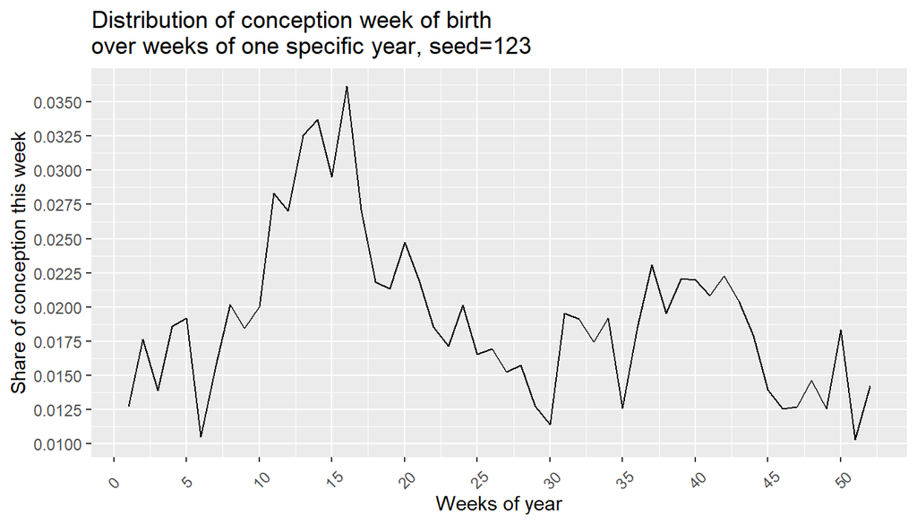

```r
# This function generates the distribution of conception weeks across
# the year, with two peak months, and some randomness
ffi_concept_distribution_year <- function(it_max_weeks = 52,
                                          it_peak_wk_1st = 15,
                                          it_peak_wk_2nd = 40,
                                          fl_binom_1st_wgt = 0.150,
                                          fl_binom_2nd_wgt = 0.075,
                                          it_runif_seed = 123,
                                          df_dist_conception_exo = NULL) {
  # # Peak (local) months and weights
  # it_max_weeks <- 52
  # it_peak_wk_1st <- 15
  # it_peak_wk_2nd <- 40

  # # Weights for the two binomial and the remaining weight is for an uniform distribution
  # fl_binom_1st_wgt <- 0.25
  # fl_binom_2nd_wgt <- 0.10

  if (is.null(df_dist_conception_exo)) {

    # Discrete random variables
    ar_fl_binom_1st <- dbinom(
      0:(it_max_weeks - 1), (it_max_weeks - 1),
      (it_peak_wk_1st - 1) / (it_max_weeks - 1)
    )
    ar_fl_binom_2nd <- dbinom(
      0:(it_max_weeks - 1), (it_max_weeks - 1),
      (it_peak_wk_2nd - 1) / (it_max_weeks - 1)
    )
    set.seed(it_runif_seed)
    ar_random_base <- runif(it_max_weeks, min = 0.5, max = 1)
    ar_random_base <- ar_random_base / sum(ar_random_base)

    # Mix two binomials and a uniform
    ar_fl_p_concept_week <- ar_fl_binom_1st * fl_binom_1st_wgt +
      ar_fl_binom_2nd * fl_binom_2nd_wgt +
      ar_random_base * (1 - fl_binom_1st_wgt - fl_binom_2nd_wgt)

    # Dataframe
    df_dist_conception <- tibble(conception_calendar_week = 1:it_max_weeks,
                                conception_prob = ar_fl_p_concept_week)

  } else {
    df_dist_conception <- df_dist_conception_exo

  }

  # Line plot
  # Title
  st_title <- paste0(
      "Distribution of conception week of birth\n",
      "over weeks of one specific year, seed=", it_runif_seed
    )

  # Display
  plt_concept_week_of_year <- df_dist_conception %>%
    ggplot(aes(x = conception_calendar_week, y= conception_prob)) +
    geom_line() +
    labs(
      title = st_title,
      x = 'Weeks of year',
      y = 'Share of conception this week'
      ) +
    scale_x_continuous(n.breaks = 12) +
    scale_y_continuous(n.breaks = 10) +
    theme(
      axis.text.x = element_text(angle = 45, vjust = 0.1, hjust = 0.1)
    )

  # Return
  return(list(
    df_dist_conception = df_dist_conception,
    plt_concept_week_of_year = plt_concept_week_of_year
  ))
}
# Call function with defaults
ls_concept <- ffi_concept_distribution_year(it_max_weeks = 52,
                                            it_peak_wk_1st = 15,
                                            it_peak_wk_2nd = 40,
                                            it_runif_seed = 123)
ls_concept$plt_concept_week_of_year
```

```r
df_dist_conception <- ls_concept$df_dist_conception
kable(df_dist_conception) %>% kable_styling_fc()
```

| conception_calendar_week | conception_prob |
| --- | --- |
| 1 | 0.0127130 |
| 2 | 0.0176571 |
| 3 | 0.0139137 |
| 4 | 0.0186053 |
| 5 | 0.0192192 |
| 6 | 0.0105366 |
| 7 | 0.0157063 |
| 8 | 0.0201894 |
| 9 | 0.0184492 |
| 10 | 0.0200423 |
| 11 | 0.0283162 |
| 12 | 0.0270358 |
| 13 | 0.0325643 |
| 14 | 0.0336904 |
| 15 | 0.0295436 |
| 16 | 0.0361683 |
| 17 | 0.0271255 |
| 18 | 0.0218356 |
| 19 | 0.0213639 |
| 20 | 0.0247214 |
| 21 | 0.0219399 |
| 22 | 0.0185480 |
| 23 | 0.0171439 |
| 24 | 0.0201420 |
| 25 | 0.0165473 |
| 26 | 0.0169517 |
| 27 | 0.0152796 |
| 28 | 0.0157608 |
| 29 | 0.0127605 |
| 30 | 0.0114004 |
| 31 | 0.0195570 |
| 32 | 0.0191672 |
| 33 | 0.0174747 |
| 34 | 0.0191898 |
| 35 | 0.0126323 |
| 36 | 0.0185624 |
| 37 | 0.0230986 |
| 38 | 0.0195683 |
| 39 | 0.0220649 |
| 40 | 0.0219644 |
| 41 | 0.0208423 |
| 42 | 0.0223014 |
| 43 | 0.0204080 |
| 44 | 0.0179026 |
| 45 | 0.0139712 |
| 46 | 0.0125547 |
| 47 | 0.0127300 |
| 48 | 0.0146663 |
| 49 | 0.0125517 |
| 50 | 0.0183537 |
| 51 | 0.0103274 |
| 52 | 0.0142397 |

## 1.3 Temperature Process Sine Wave and AR(1)

Let $t$ index day of survey. We model temperature in Fahrenheit as $F_{t}$ using an [AR(1) persistent process](https://fanwangecon.github.io/M4Econ/panel/timeseries/htmlpdfm/fs_autoregressive.html) and a sine function. According to [Wikipedia](https://en.wikipedia.org/wiki/Guangzhou#Climate), which reports Climate data for Guangzhou, China, daily mean temperature varies between 57F (Jan) and 84F (June). Record high temperature was reported in July at 102.4F. Record low temperature was reported in December at 32.0F. We will mark out these temperature levels visually in graphs below.

Specifically, temperature in Fahrenheit is modeled as:
$$F_{t} = \exp\left(
\mu +
\epsilon_t +
\gamma \sin
\left(
\frac{W_t}{52}\cdot 2\cdot\pi + \frac{3-\frac{1}{6}}{2}\cdot\pi
\right)
\right)$$
where $\gamma$ scales the sine curve, and the shock process $\epsilon$ follows a AR(1) process:
$$\epsilon_{t} = \rho \cdot \epsilon_{t-1} + \nu_t$$
with $0<\rho<1$, and $\nu \sim N\left(0, \sigma_\nu\right)$. Using the function above, the coldest month will be somewhere around january.

Below, we formulate the temperature simulation function *ffi_daily_temp_simulation()*.

```r
ffi_daily_temp_simulation <- function(
  fl_mthly_mean_lowest = 57,
  fl_mthly_mean_highest = 84,
  fl_record_lowest = 32,
  fl_record_highest = 102.4,
  it_weeks_in_year = 52,
  it_days_in_week = 7,
  it_years = 6,
  fl_mu = 4.15,
  fl_sin_scaler = 0.20,
  fl_sigma_nv = 0.15,
  fl_rho_persist = 0.40,
  it_rand_seed = 123,
  st_extreme_cold_percentile = "p05",
  st_extreme_heat_percentile = "p95"
){
  # # Guangzhou temp info
  # fl_mthly_mean_lowest <- 57
  # fl_mthly_mean_highest <- 84
  # fl_record_lowest <- 32
  # fl_record_highest <- 102.4

  # # Total number of periods (over three years)
  # it_weeks_in_year <- 52
  # it_days_in_week <- 7
  # it_years <- 6
  it_max_days <- it_weeks_in_year*it_days_in_week
  T <- it_max_days * it_years

  # # Mean temp
  # fl_mu <- 4.15
  # fl_sin_scaler <- 0.20
  # # AR 1 parameter
  # fl_sigma_nv <- 0.15
  # fl_rho_persist <- 0.40

  # Generate a vector of shocks
  set.seed(it_rand_seed)
  ar_nv_draws <- rnorm(T, mean = 0, sd = fl_sigma_nv)

  # Generate a vector of epsilons
  ar_epsilon_ar1 <- vector("double", length=T)
  ar_epsilon_ar1[1] <- ar_nv_draws[1]
  for (it_t in 2:T) {
    ar_epsilon_ar1[it_t] <- fl_rho_persist*ar_epsilon_ar1[it_t-1] + ar_nv_draws[it_t]
  }

  # Generate week by week sin curve values
  ar_day_at_t <- rep(1:it_max_days, it_years)
  ar_year_at_t <- as.vector(t(matrix(data=rep(1:it_years, it_max_days),
                                     nrow=it_years, ncol=it_max_days)))
  ar_base_temp <- sin((ar_day_at_t/it_max_days)*2*pi + ((3-1/6)/2)*pi)

  # Generate overall temperature in Fahrenheit
  ar_fahrenheit_city_over_t <-
    exp(fl_mu + ar_epsilon_ar1 + fl_sin_scaler*ar_base_temp)

  # Dataframe with Temperatures
  mt_fahrenheit_info <- cbind(ar_day_at_t, ar_year_at_t, ceiling(ar_day_at_t/it_days_in_week),
    ar_fahrenheit_city_over_t,
    exp(ar_base_temp), ar_epsilon_ar1, ar_nv_draws)
  ar_st_varnames <- c('survey_t','day_of_year', 'year', 'week_of_year',
    'Fahrenheit', 'FnoShock', 'AR1Shock', 'RandomDraws')

  # Combine to tibble, add name col1, col2, etc.
  df_fahrenheit <- as_tibble(mt_fahrenheit_info) %>%
    rowid_to_column(var = "t") %>%
    rename_all(~c(ar_st_varnames))

  # Generate extreme temperatures
  df_stats_fahrenheit <- REconTools::ff_summ_percentiles(df_fahrenheit, FALSE)
  # Add Extreme Thresholds
  fl_lowF_threshold <- df_stats_fahrenheit %>% filter(var == "Fahrenheit") %>% pull(st_extreme_cold_percentile)
  fl_highF_threshold <- df_stats_fahrenheit %>% filter(var == "Fahrenheit") %>% pull(st_extreme_heat_percentile)
  df_fahrenheit <- df_fahrenheit %>%
    mutate(extreme_cold = case_when(Fahrenheit <= fl_lowF_threshold ~ 1, TRUE ~ 0)) %>%
    mutate(extreme_hot = case_when(Fahrenheit >= fl_highF_threshold ~ 1, TRUE ~ 0))
  # REconTools::ff_summ_percentiles(df_fahrenheit, FALSE)

  # Title
  st_title <- paste0('Simulated Temperature for Guangzhou (Sine Wave + AR(1))\n',
      'Each subplot is a different year\n',
      'RED = Guangzhou Temp 1971–2000 lowest and highest monthly averages\n',
      'BLUE = Guangzhou Temp 1961–2000 record lows and highs')

  # Display
  plt_fahrenheit <- df_fahrenheit %>%
    ggplot(aes(x = ar_day_at_t, y=Fahrenheit)) +
    geom_line() +
    geom_hline(yintercept = fl_mthly_mean_lowest, linetype = "solid", colour = "red", size = 1) +
    geom_hline(yintercept = fl_mthly_mean_highest, linetype = "solid", colour = "red", size = 1) +
    geom_hline(yintercept = fl_record_lowest, linetype = "dashed", colour = "blue", size = 1) +
    geom_hline(yintercept = fl_record_highest, linetype = "dashed", colour = "blue", size = 1) +
    facet_wrap(~ year) +
    labs(
      title = st_title,
      x = 'Calendar day in year',
      y = 'Temperature in Fahrenheit'
      ) +
    scale_x_continuous(n.breaks = 12) +
    scale_y_continuous(n.breaks = 10) +
    theme(
      axis.text.x = element_text(angle = 45, vjust = 0.1, hjust = 0.1)
    )

  # Return
  return(list(
    df_fahrenheit = df_fahrenheit,
    plt_fahrenheit = plt_fahrenheit
  ))
}
```

Having constructed the temperature simulation function, first we call it with AR1 shock + sin curve, persistence is high at $\rho=0.7$.

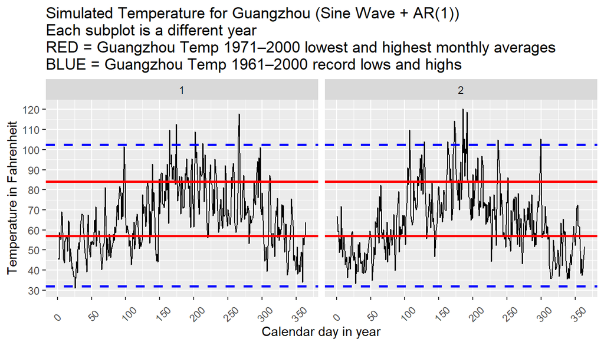

```r
# Test 1: Call function with AR1 + Since Curve
ls_fahrenheit <- ffi_daily_temp_simulation(
  fl_mthly_mean_lowest = 57,
  fl_mthly_mean_highest = 84,
  fl_record_lowest = 32,
  fl_record_highest = 102.4,
  it_weeks_in_year = 52,
  it_days_in_week = 7,
  it_years = 2,
  fl_mu = 4.15,
  fl_sin_scaler = 0.25,
  fl_sigma_nv = 0.15,
  fl_rho_persist = 0.70,
  it_rand_seed = 123)
print(ls_fahrenheit$plt_fahrenheit)
```

```r
# df_fahrenheit <- ls_fahrenheit$df_fahrenheit
# kable(df_fahrenheit) %>% kable_styling_fc()
```

Second, we call the same temperature function, but we reduce shock persistence to 0.

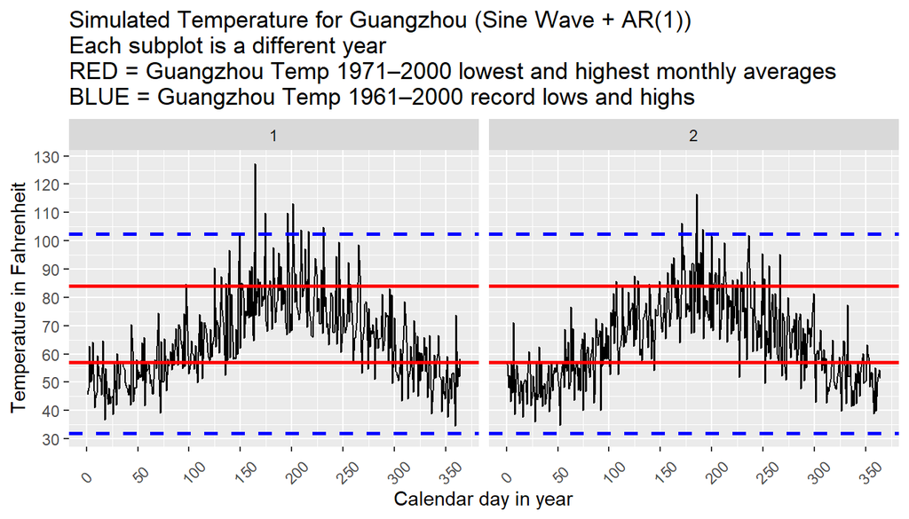

```r
# Test 2: Call function with defaults
ls_fahrenheit <- ffi_daily_temp_simulation(
  fl_mthly_mean_lowest = 57,
  fl_mthly_mean_highest = 84,
  fl_record_lowest = 32,
  fl_record_highest = 102.4,
  it_weeks_in_year = 52,
  it_days_in_week = 7,
  it_years = 2,
  fl_mu = 4.15,
  fl_sin_scaler = 0.25,
  fl_sigma_nv = 0.15,
  fl_rho_persist = 0.0,
  it_rand_seed = 123)
# Show
print(ls_fahrenheit$plt_fahrenheit)
```

```r
# df_fahrenheit <- ls_fahrenheit$df_fahrenheit
# kable(df_fahrenheit) %>% kable_styling_fc()
```

Third, we call the same temperature function, but we reduce shock persistence to 0 and shock variance to almost zero.

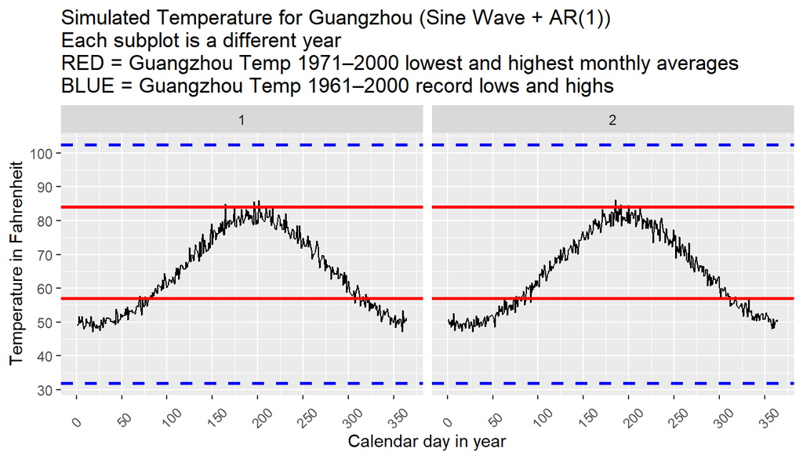

```r
# Test 2: Call function with defaults
ls_fahrenheit <- ffi_daily_temp_simulation(
  fl_mthly_mean_lowest = 57,
  fl_mthly_mean_highest = 84,
  fl_record_lowest = 32,
  fl_record_highest = 102.4,
  it_weeks_in_year = 52,
  it_days_in_week = 7,
  it_years = 2,
  fl_mu = 4.15,
  fl_sin_scaler = 0.25,
  fl_sigma_nv = 0.025,
  fl_rho_persist = 0.0,
  it_rand_seed = 123)
# Show
print(ls_fahrenheit$plt_fahrenheit)
```

```r
# df_fahrenheit <- ls_fahrenheit$df_fahrenheit
# kable(df_fahrenheit) %>% kable_styling_fc()
```

## 1.4 Distributions of Conception, Birth, Temperature and Pre-Term

We will simulate several datasets on birth and relate to temperature distributions. Below we do that, we go through several key points that will be confirmed/demonstrated by the simulations.

### 1.4.1 Conception and Birth Marginal and Joint Distributions

There are three relevant distributional concepts here:

- $P(C_i)$: From *ffi_concept_distribution_year()* function generated earlier, this is the marginal discrete distribution of conception by calendar week of the year (perhaps some months are more popular for conception than others). C stands for conception.
- $P(B_i)$: From *ffi_gestation_age_at_birth_dist()* function generated earlier, $P(B_i-C_i)$ is the marginal discrete distribution of gestational age by birth by day/week of gestation. B stands for birth.
- $P(C_i, B_i-C_i)$: the joint distribution of C_i and B_i. If they are unrelated, than at each conception day, the conditional distribution of gestational age at birth is identical. To allow for arbitrary correlation between conception and gestational-age, we can draw from some mixture of joint normal distribution with some set of variance-covariance matrixes, invert to the draws to quantiles along each dimension, and then map the quantiles to discrete outcomes along $C$ and $B$ dimensions.

### 1.4.2 Extreme Temperature and Pre-Term Births

Pre-term birth or not is determined jointly by the gestational age at birth and conception date distributions, which determine the conception and birth dates. We establish a common threshold below which a birth is considered pre-term.

Extreme temperature and whether a child is pre-term or not can be related.

Under **scenario (A)**, conception dates are uniformly distribution across the year, and gestational age at birth is unrelated to conception time. Given this, extreme temperature or not has nothing to do with gestational age at birth.

Under **scenario (B)**, we can spuriously have pre-term experiencing less extreme-cold/heat when $P(C_i)$ is non-uniform/random, meaning $P(C_i) \neq \frac{1}{\text{CountTotalDatesOfConception}}$. This could go in several directions:

1. Under **scenario (B.1)**, suppose all conception starts in Jan. and all extreme temp happen in Oct. Suppose pre-term means birth in Sep. rather than Nov.. If all extreme cold takes place in Oct. Then all pre-term births will not have experienced extreme cold. So the potential direction for spuriousness here is that pre-term will be correlated with less extreme temp. This is fixed by a conception month fixed effect.
2. Under **scenario (B.2)**, suppose all conception starts in August. and all extreme temp happen in Oct. The number of extreme cold days will be the same under both pre-term and full-term birth groups, but the percentage of days exposed to extreme cold will be greater for the pre-term individuals, a spurious relationship again.
3. Under **Scenario (B.3)**, we use the actual distribution of conception from Guangzhou China. Will the results be more similar to **scenarior (A)**, where conception was uniformly distribution? Or more similar to **scenario B.1** with a greater concentration of conception earlier in the year, or **scenario B.2** with a greater concentration of conception later in the year?

Additionally, pre-term could experience more extreme-cold under **scenario (C.1)**, where extreme temperature has a causal impact on gestational-age, causally leading to more pre-term. This is the research hypothesis of interest.

But pre-term could also experience more extreme-cold under **scenario (C.2)** for another reason. Suppose the distribution of high-pregnancy-risk parents/mothers across calendar month in each year is non-random: if all high risk mother get pregnant in August, and low risk mother get pregnant in March, we might end up with full-term births not experiencing extreme temperature, but pre-term births experiencing a lot of extreme-cold days. The pre-term births (likely with lower birthweight) is correlated with cold exposures, but this correlation due to the conception timing of high-risk pregnancies. In this situation, cold might not real effects on whether a birth is pre-term or not.

### 1.4.3 Days and Percent of Gestational Days Exposed to Cold

The share/percentage of days exposed to exposure cold is the appropriate measure to use. As seen in the scenarios above, it does not generate “spurious relationships” due to shorter time spans of pre-term births.

In the exercises below, we only simulate Scenarios (A) and (B) for now.

## 1.5 Simulating Datasets on Extreme Temperature Exposures Across Pregnancies

### 1.5.1 Simulate and Compute Extreme Temperature Exposure

- Conception draws $P(C_i)$: For each of the $N$ individuals, we first draw week of conception from the week of conception distribution function (adjust distribution depending on number of years and the starting month), then we draw the day of week of conception randomly, and the year of conception randomly as well.
- Gestation draws $P(B_i - C_i)$: For each of the $N$ individuals, we draw from the gestational week at the time of birth distribution the number of weeks of gestation, multiply this by seven and add a random number between 1 to 7.
- Joint distribution $P(C_i, B_i-C_i)$: For the simulation below, the draws for day of birth is independent from the draws for gestational age at time of birth.

First, we create a function for generating birth conception and gestational distributions.

```r
ffi_pop_concept_birth_simu <- function(
  it_pop_n = 50000,
  it_days_in_week = 7,
  it_weeks_in_month = 4,
  it_months_in_year = 12,
  it_years = 3,
  it_rng_seed = 123,
  fl_pre_term_ratio = 0.84,
  fl_peak_concept_frac_of_year_1st = 0.3,
  fl_peak_concept_frac_of_year_2nd = 0.9,
  fl_binom_1st_wgt = 0.15,
  fl_binom_2nd_wgt = 0.05,
  fl_mu_gabirth_days_365 = 276,
  fl_sd_gabirth_days_365 = 14,
  df_dist_conception_exo = NULL
) {

  # # 1. Define parameters
  # # 1.a Number of individuals of interest
  # it_pop_n <- 50000
  # # 1.b Number of days per week, week per month
  # # for simplicity, 7 days per week, 4 weeks per month, 12 months
  # it_days_in_week <- 7
  # it_weeks_in_month <- 4
  # it_months_in_year <- 12
  # it_years <- 3
  # # 1.c random draw seed
  # it_rng_seed <- 123
  # # 1.d pre-term threshold
  # # what fraction of maximum pregnancy length is pre-term?
  # # Max length 44 weeks for example, 44*0.85 is about 37 months.
  # fl_pre_term_ratio <- 0.84

  # 1.e Other dates
  it_weeks_in_year <- it_weeks_in_month*it_months_in_year
  it_days_in_month <- it_days_in_week*it_weeks_in_month
  it_days_in_year <- it_days_in_week*it_weeks_in_month*it_months_in_year
  # 1.f Month of conception distribution
  it_peak_wk_1st <- round(it_weeks_in_year*fl_peak_concept_frac_of_year_1st)
  it_peak_wk_2nd <- round(it_weeks_in_year*fl_peak_concept_frac_of_year_2nd)
  # fl_binom_1st_wgt <- 0.15
  # fl_binom_2nd_wgt <- 0.05
  # # 1.g Gestational age at birth distribution parameters
  mu_gabirth_days <- round((fl_mu_gabirth_days_365/365)*it_days_in_year)
  sd_gabirth_days <- round((fl_sd_gabirth_days_365/365)*it_days_in_year)

  # 2. Date of conception random draws
  # 2.a Week of conception distribution
  ls_concept_fc <- ffi_concept_distribution_year(
    it_max_weeks = it_weeks_in_year,
    it_peak_wk_1st = it_peak_wk_1st, it_peak_wk_2nd = it_peak_wk_2nd,
    fl_binom_1st_wgt = fl_binom_1st_wgt, fl_binom_2nd_wgt = fl_binom_2nd_wgt,
    it_runif_seed = it_rng_seed*210,
    df_dist_conception_exo = df_dist_conception_exo)
  df_dist_conception_week <- ls_concept_fc$df_dist_conception
  # 2.b.1 Randomly (uniformly) drawing the day of birth
  set.seed(it_rng_seed*221)
  ar_draws_conception_day_of_week <- sample(
    it_days_in_week, it_pop_n, replace=TRUE)
  # 2.b.2 Week of conception draws
  set.seed(it_rng_seed*222)
  ar_draws_conception_week <- sample(
    df_dist_conception_week$conception_calendar_week,
    it_pop_n,
    prob=df_dist_conception_week$conception_prob,
    replace=TRUE)
  # 2.b.3 Randomly (uniformly) drawing the year of conception
  set.seed(it_rng_seed*223)
  ar_draws_conception_year <- sample(
    it_years, it_pop_n, replace=TRUE)
  # 2.c Date of birth
  ar_draws_concept_date <- (ar_draws_conception_year-1)*it_days_in_year +
    (ar_draws_conception_week-1)*it_days_in_week +
    ar_draws_conception_day_of_week
  ar_draws_conception_day_of_year <- (ar_draws_conception_week-1)*it_days_in_week +
    ar_draws_conception_day_of_week

  # 3. Gestational age at birth distribution simulation
  # 3.a Gestational age distribution
  ls_gsbirth_fc <- ffi_gestation_age_at_birth_dist(
    mu_gabirth_days = mu_gabirth_days, sd_gabirth_days = sd_gabirth_days)
  df_dist_gabirth <- ls_gsbirth_fc$df_dist_gabirth
  # 3.b.1 Gestational day of week draws (random)
  set.seed(it_rng_seed*321)
  ar_draws_gsbirth_day_of_week <- sample(
    it_days_in_week, it_pop_n, replace=TRUE)
  # 3.b.2 Gestational week draws
  set.seed(it_rng_seed*322)
  ar_draws_gsbirth_week <- sample(
    df_dist_gabirth$gabirth,
    it_pop_n,
    prob=df_dist_gabirth$prob,
    replace=TRUE)
  # 3.c Gestational days at birth
  ar_draws_gsbirth_day <- ar_draws_gsbirth_week*it_days_in_week + ar_draws_gsbirth_day_of_week
  ar_draws_birth_date <- ar_draws_concept_date + ar_draws_gsbirth_day

  # 4. Create dataframe
  # 4.a Variables and labels
  mt_birth_data <- cbind(
    ar_draws_concept_date, ar_draws_birth_date, ar_draws_gsbirth_day,
    ar_draws_conception_year, ar_draws_conception_week,
    ar_draws_conception_day_of_week, ar_draws_conception_day_of_year,
    ar_draws_gsbirth_week, ar_draws_gsbirth_day_of_week)
  ar_st_varnames <- c('id',
    'survey_date_conception', 'survey_date_birth', 'gestation_length_in_days',
    'conception_year', 'conception_week',
    'conception_day_of_week', 'concept_day_of_year',
    'gestational_week_at_birth', 'gestational_day_of_week_at_birth')
  # 4.b tibble with conception and birth data
  df_birth_data <- as_tibble(mt_birth_data) %>%
    rowid_to_column(var = "id") %>%
    rename_all(~c(ar_st_varnames)) %>%
    arrange(survey_date_conception, survey_date_birth)
  # 4.c generate cut-off for preterm
  it_pre_term_threshold <- round(fl_pre_term_ratio*length(df_dist_gabirth$gabirth)*it_days_in_week)
  df_birth_data <- df_birth_data %>% mutate(
    preterm = case_when(it_pre_term_threshold >= gestation_length_in_days ~ 1,
                        TRUE ~ 0) )

  # 5. Display data
  # Display
  st_title <- paste0('Day of year of conception and gestational age at birth\n',
    'pop=', it_pop_n, ', days-in-year=', it_days_in_year, ', seed=', it_rng_seed, '\n',
    'mean-ga-at-birth-in-month=', round(mu_gabirth_days/it_days_in_month, 3),
    ', sd-ga-at-birth-in-month=', round(sd_gabirth_days/it_days_in_month, 3))
  plt_concept_birth <- df_birth_data %>%
    mutate(preterm = factor(preterm)) %>%
    ggplot(aes(x = concept_day_of_year, y=gestation_length_in_days, color=preterm)) +
    facet_wrap(~ conception_year) +
    geom_point() +
    labs(
      title = st_title,
      x = 'Calendar day in year',
      y = 'Gestational age in days at birth'
      ) +
    scale_x_continuous(n.breaks = 12) +
    scale_y_continuous(n.breaks = 10) +
    theme(
      axis.text.x = element_text(angle = 45, vjust = 0.1, hjust = 0.1)
    )
  # print(plt_concept_birth)
  # kable(df_birth_data) %>% kable_styling_fc_wide()
  # plot(df_birth_data$survey_date_conception, df_birth_data$gestation_length_in_days)

  # Return
  return(list(
    df_birth_data = df_birth_data,
    plt_concept_birth = plt_concept_birth,
    ls_concept_fc = ls_concept_fc,
    ls_gsbirth_fc = ls_gsbirth_fc
  ))
}
```

### 1.5.2 Scenario (A) Simulation, Uniform Conception

We generate a dataframe where the conception months are randomly/uniformly distributed, and there is no correlation between conception and gestation. This is **Scenario (A)**.

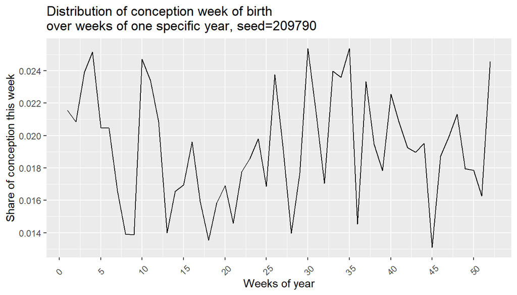

```r
# Define some dates
it_days_in_week <- 7
it_weeks_in_month <- 4
it_months_in_year <- 13
it_years <- 3
# Simulate
ls_concept_birth <- ffi_pop_concept_birth_simu(
  it_pop_n = 10000,
  it_days_in_week = it_days_in_week,
  it_weeks_in_month = it_weeks_in_month,
  it_months_in_year = it_months_in_year,
  it_years = it_years,
  it_rng_seed = 999,
  fl_pre_term_ratio = 0.84,
  fl_peak_concept_frac_of_year_1st = 0.3,
  fl_peak_concept_frac_of_year_2nd = 0.9,
  fl_binom_1st_wgt = 0.00,
  fl_binom_2nd_wgt = 0.00,
  fl_mu_gabirth_days_365 = 276,
  fl_sd_gabirth_days_365 = 14
)
# Get dataframe and print distribution
df_birth_data_rand_cor0 <- ls_concept_birth$df_birth_data
print(ls_concept_birth$ls_concept_fc$plt_concept_week_of_year)
```

```r
print(ls_concept_birth$ls_gsbirth_fc$plt_dist_gabirth)
```

[output not shown]

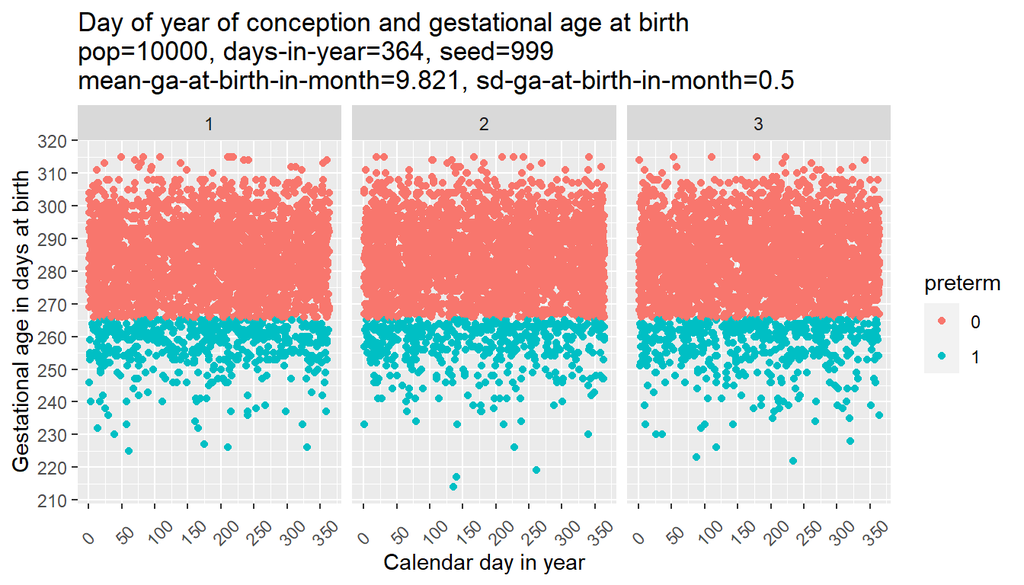

```r
print(ls_concept_birth$plt_concept_birth)
```

### 1.5.3 Scenario (B.1) Simulation, Nearly All Conceptions in Feb.

We generate a dataframe where the conception distribution has a high peak around Feb, and there is no correlation between conception and gestation. This is **Scenario (B.1)**.

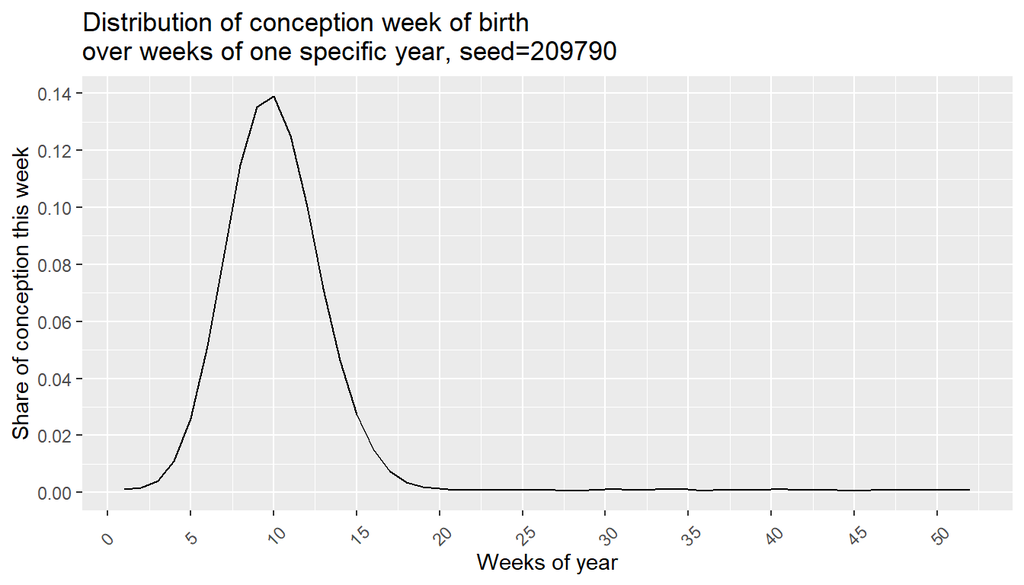

```r
# Simulate
ls_concept_birth <- ffi_pop_concept_birth_simu(
  it_pop_n = 10000,
  it_days_in_week = it_days_in_week,
  it_weeks_in_month = it_weeks_in_month,
  it_months_in_year = it_months_in_year,
  it_years = it_years,
  it_rng_seed = 999,
  fl_pre_term_ratio = 0.84,
  fl_peak_concept_frac_of_year_1st = 0.2,
  fl_peak_concept_frac_of_year_2nd = 0.9,
  fl_binom_1st_wgt = 0.95,
  fl_binom_2nd_wgt = 0.00,
  fl_mu_gabirth_days_365 = 276,
  fl_sd_gabirth_days_365 = 14
)
# Get dataframe and print distribution
df_birth_data_CFeb_cor0 <- ls_concept_birth$df_birth_data
print(ls_concept_birth$ls_concept_fc$plt_concept_week_of_year)
```

```r
print(ls_concept_birth$ls_gsbirth_fc$plt_dist_gabirth)
```

[output not shown]

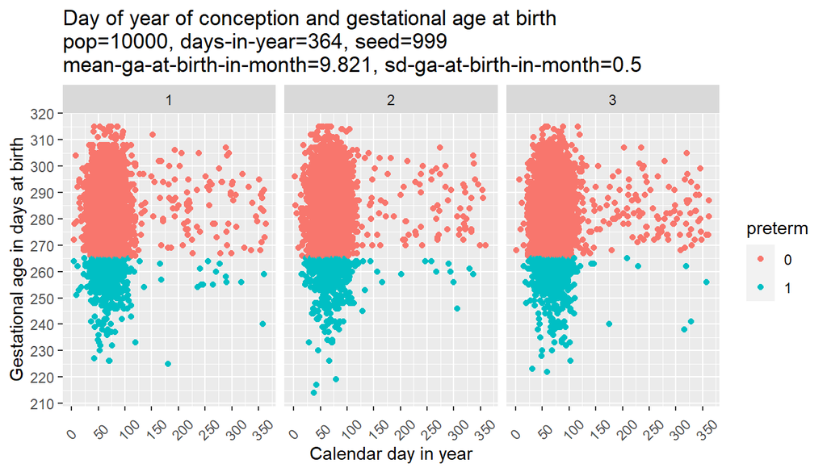

```r
print(ls_concept_birth$plt_concept_birth)
```

### 1.5.4 Scenario (B.2) Simulation, Nearly All Conceptions in Oct.

We generate a dataframe where the conception distribution has a high peak around October, and there is no correlation between conception and gestation. This is **Scenario (B.2)**.

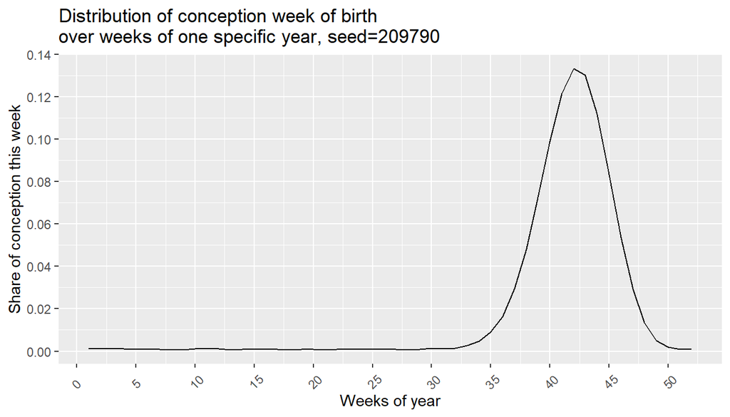

```r
# Simulate
ls_concept_birth <- ffi_pop_concept_birth_simu(
  it_pop_n = 10000,
  it_days_in_week = it_days_in_week,
  it_weeks_in_month = it_weeks_in_month,
  it_months_in_year = it_months_in_year,
  it_years = it_years,
  it_rng_seed = 999,
  fl_pre_term_ratio = 0.84,
  fl_peak_concept_frac_of_year_1st = 0.2,
  fl_peak_concept_frac_of_year_2nd = 0.8,
  fl_binom_1st_wgt = 0.0,
  fl_binom_2nd_wgt = 0.95,
  fl_mu_gabirth_days_365 = 276,
  fl_sd_gabirth_days_365 = 14
)
# Get dataframe and print distribution
df_birth_data_COct_cor0 <- ls_concept_birth$df_birth_data
print(ls_concept_birth$ls_concept_fc$plt_concept_week_of_year)
```

```r
print(ls_concept_birth$ls_gsbirth_fc$plt_dist_gabirth)
```

[output not shown]

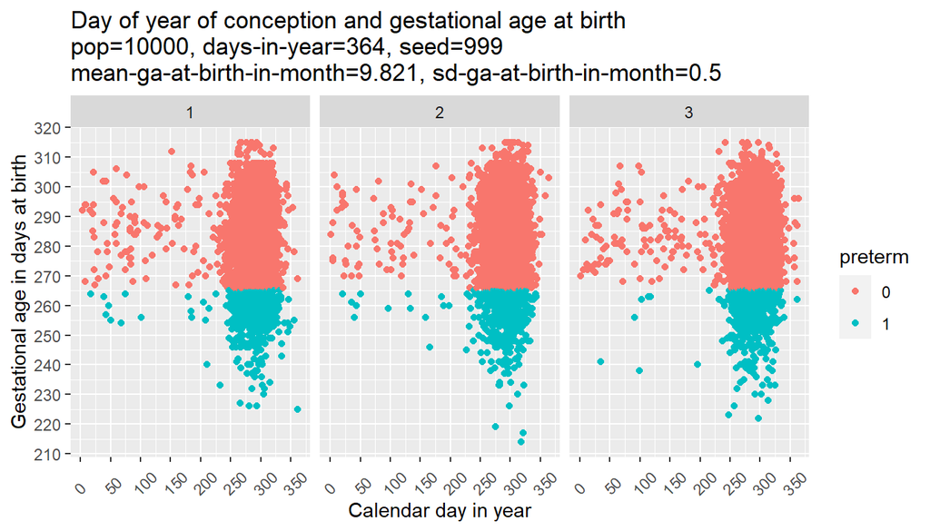

```r
print(ls_concept_birth$plt_concept_birth)
```

### 1.5.5 Scenario (B.3) Simulation, Guangzhou Actual from Liu et al. Conception Distribution

We generate a dataframe based on the actual conception distribution in Guangzhou, China from a particular survey year. Is this more similar to Scenarios **A, B.1 or B.2**? The data is from [Same Environment, Stratified Impacts? Air Pollution, Extreme Temperatures, and Birth Weight in South China](https://fanwangecon.github.io/assets/FanWang_PollutionTempBirthweight.pdf).

```r
st_dist_conception_lbhwz_actual <- "conception_calendar_week, conception_prob
    1,  0.0237
    2,  0.0221
    3,  0.0217
    4,  0.0202
    5,  0.0226
    6,  0.0232
    7,  0.0223
    8,  0.0214
    9,  0.0161
    10, 0.0183
    11, 0.0213
    12, 0.0191
    13, 0.0191
    14, 0.0201
    15, 0.0196
    16, 0.0200
    17, 0.0184
    18, 0.0184
    19, 0.0173
    20, 0.0186
    21, 0.0204
    22, 0.0219
    23, 0.0180
    24, 0.0181
    25, 0.0171
    26, 0.0160
    27, 0.0167
    28, 0.0172
    29, 0.0165
    30, 0.0160
    31, 0.0182
    32, 0.0180
    33, 0.0184
    34, 0.0160
    35, 0.0187
    36, 0.0170
    37, 0.0187
    38, 0.0180
    39, 0.0190
    40, 0.0180
    41, 0.0186
    42, 0.0198
    43, 0.0172
    44, 0.0195
    45, 0.0203
    46, 0.0197
    47, 0.0184
    48, 0.0180
    49, 0.0215
    50, 0.0195
    51, 0.0222
    52, 0.0242"
# Raw probability data to table
df_dist_conception_lbhwz_actual = read.csv(text=st_dist_conception_lbhwz_actual, header=TRUE)
ar_st_varnames <- c('conception_calendar_week',
                    'conception_prob')
tb_dist_conception_lbhwz_actual <- as_tibble(df_dist_conception_lbhwz_actual) %>%
  rename_all(~c(ar_st_varnames)) %>%
  mutate(conception_prob = conception_prob/sum(conception_prob))

# Summarize
summary(tb_dist_conception_lbhwz_actual)
```

```
##  conception_calendar_week conception_prob
##  Min.   : 1.00            Min.   :0.01600
##  1st Qu.:13.75            1st Qu.:0.01799
##  Median :26.50            Median :0.01869
##  Mean   :26.50            Mean   :0.01923
##  3rd Qu.:39.25            3rd Qu.:0.02032
##  Max.   :52.00            Max.   :0.02419
```

```r
# Check Probability sums to 1
sum(tb_dist_conception_lbhwz_actual$conception_prob)
```

```
## [1] 1
```

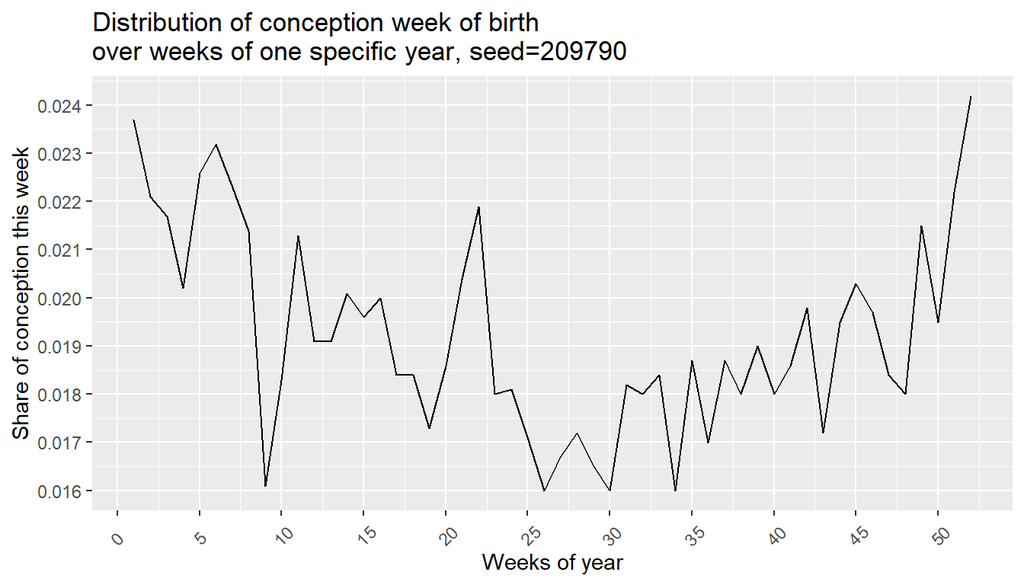

```r
# Simulate
ls_concept_birth <- ffi_pop_concept_birth_simu(
  it_pop_n = 10000,
  it_days_in_week = it_days_in_week,
  it_weeks_in_month = it_weeks_in_month,
  it_months_in_year = it_months_in_year,
  it_years = it_years,
  it_rng_seed = 999,
  fl_pre_term_ratio = 0.84,
  fl_peak_concept_frac_of_year_1st = 0.2,
  fl_peak_concept_frac_of_year_2nd = 0.9,
  fl_binom_1st_wgt = 0.95,
  fl_binom_2nd_wgt = 0.00,
  fl_mu_gabirth_days_365 = 276,
  fl_sd_gabirth_days_365 = 14,
  df_dist_conception_exo = tb_dist_conception_lbhwz_actual
)
# Get dataframe and print distribution
df_birth_data_Clbhwz_cor0 <- ls_concept_birth$df_birth_data
print(ls_concept_birth$ls_concept_fc$plt_concept_week_of_year)
```

```r
print(ls_concept_birth$ls_gsbirth_fc$plt_dist_gabirth)
```

[output not shown]

[figure not shown]

```r
print(ls_concept_birth$plt_concept_birth)
```

## 1.6 Compute Extreme Temperature Exposure

we simulate temperature corresponding to the span of data of interest that covers all individuals’ potential course of pregnancy. We loop over each individual, and calculate the individual-specific extreme temperature exposure. Specifically, we store the percentage of days during pregnancy exposed to extreme cold or extreme hot. We use as threshold 5 percent temperature extreme tails. We also store the number of days as well as the percent of gestational days that are exposed to extreme cold or hot.

First, we generate the temperature distribution along with extreme cold and hot days.

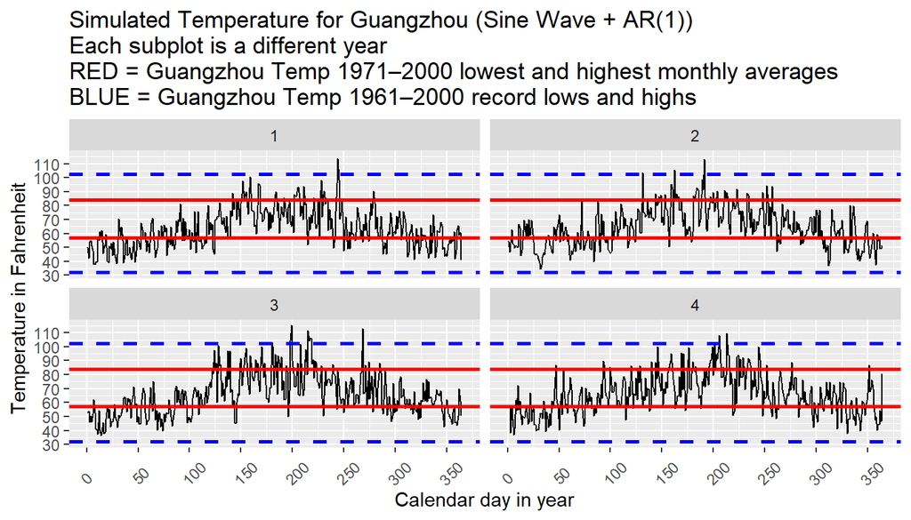

```r
# Simulate the temperature distribution using just define parameters
ls_fahrenheit <- ffi_daily_temp_simulation(
  fl_mthly_mean_lowest = 57,
  fl_mthly_mean_highest = 84,
  fl_record_lowest = 32,
  fl_record_highest = 102.4,
  it_weeks_in_year = it_months_in_year*it_weeks_in_month,
  it_days_in_week = it_days_in_week,
  it_years = it_years+1,
  it_rand_seed = 999,
  st_extreme_cold_percentile = "p05",
  st_extreme_heat_percentile = "p95")
print(ls_fahrenheit$plt_fahrenheit)
```

```r
df_fahrenheit <- ls_fahrenheit$df_fahrenheit
summary(df_fahrenheit$Fahrenheit)
```

```
##    Min. 1st Qu.  Median    Mean 3rd Qu.    Max.
##   34.46   54.57   63.42   65.07   74.42  115.24
```

```r
df_stats_fahrenheit <- REconTools::ff_summ_percentiles(df_fahrenheit, FALSE)
```

Second, for one individual, we test computing the number of days exposed to extreme cold.

```r
# Define the extreme cold function
ffi_extreme_cold_percent_gestation <- function(df_fahrenheit, it_date_conception, it_date_birth){

  # get extreme cold
  ar_extreme_cold <- df_fahrenheit %>%
    filter(survey_t >= it_date_conception & survey_t <= it_date_birth) %>% pull(extreme_cold)

  # extreme cold days
  it_extreme_cold_days <- sum(ar_extreme_cold)

 return(it_extreme_cold_days)
}
# Test the function
it_extreme_cold_days <- ffi_extreme_cold_percent_gestation(df_fahrenheit, 11, 200)
print(it_extreme_cold_days)
```

```
## [1] 9
```

Third, we create a function that takes the birth dataframe and temperature dataframe as inputs and generate extreme cold days exposure for each pregancy in the birth dateaframe using [apply with an anonymous function](https://fanwangecon.github.io/R4Econ/function/noloop/htmlpdfr/fs_apply.html#122_anonymous_function).

```r
# Given two dataframes with birth data and temperature data, find cold exposure
ffi_birth_extreme_exposure <- function(df_birth_data, df_fahrenheit){
  # apply row by row, anonymous function
  # see: https://fanwangecon.github.io/R4Econ/function/noloop/htmlpdfr/fs_apply.html#122_anonymous_function
  mt_birth_cold <- apply(df_birth_data, 1, function(row) {

      id <- row[1]
      it_date_conception <- row[2]
      it_date_birth <- row[3]
      it_week_of_year_conception <- row[6]
      it_preterm <- row[11]

      it_extreme_cold_days <- ffi_extreme_cold_percent_gestation(
        df_fahrenheit, it_date_conception, it_date_birth)

      mt_all_res <- cbind(id, it_date_conception, it_week_of_year_conception,
                          it_date_birth,
                          it_preterm, it_extreme_cold_days)

      return(mt_all_res)
    })

  # Column Names
  ar_st_varnames <- c('id',
                      'survey_date_conception', 'week_of_year_conception',
                      'survey_date_birth',
                      'preterm', 'days_extreme_cold')

  # Combine to tibble, add name col1, col2, etc.
  tb_birth_cold <- as_tibble(t(mt_birth_cold)) %>%
    rename_all(~c(ar_st_varnames)) %>%
    mutate(days_extreme_cold_percent = days_extreme_cold/(survey_date_birth-survey_date_conception)) %>%
    mutate(month_of_year_conception = round(week_of_year_conception/it_weeks_in_month))

  # Show Results
  # kable(tb_birth_cold[1:20,]) %>% kable_styling_fc()
  return(tb_birth_cold)
}
```

Fourth, we generate cold exposures for the datasets we generated using the same temperature dataframe by different birth/conception dataframes created under different assumptions. We use the *ffi_birth_extreme_exposure* function just created.

```r
# Scenario (A)
tb_birth_cold_rand_cor0 <- ffi_birth_extreme_exposure(df_birth_data_rand_cor0, df_fahrenheit)
# Scenario (B.1)
tb_birth_cold_CFeb_cor0 <- ffi_birth_extreme_exposure(df_birth_data_CFeb_cor0, df_fahrenheit)
# Scenario (B.2)
tb_birth_cold_COct_cor0 <- ffi_birth_extreme_exposure(df_birth_data_COct_cor0, df_fahrenheit)
# Scenario (B.3)
tb_birth_cold_Clbhwz_cor0 <- ffi_birth_extreme_exposure(df_birth_data_Clbhwz_cor0, df_fahrenheit)
```

### 1.6.1 Regression pre-term Births and Extreme Temperature Exposures

In the four datasets that we have generated, each under a different set of conception date distribution assumptions, we have information on the binary prer-term outcome and extreme cold exposure for each individual. We now regress pre-term on extreme cold exposures.

In the regression under **Scenarior (A)**, percent of extreme cold days is unrelated to pre-term.

```r
# Scenarior (A) regression based on percent of days, with month of year conception fixed effects
re_esti_cold_rand_cor0 <- lm(preterm ~ days_extreme_cold_percent + factor(month_of_year_conception),
  data=tb_birth_cold_rand_cor0)
summary(re_esti_cold_rand_cor0)
```

```
##
## Call:
## lm(formula = preterm ~ days_extreme_cold_percent + factor(month_of_year_conception),
##     data = tb_birth_cold_rand_cor0)
##
## Residuals:
##     Min      1Q  Median      3Q     Max
## -0.1833 -0.1525 -0.1451 -0.1375  0.8941
##
## Coefficients:
##                                     Estimate Std. Error t value Pr(>|t|)
## (Intercept)                         0.151680   0.021404   7.086 1.47e-12 ***
## days_extreme_cold_percent           0.082741   0.315434   0.262   0.7931
## factor(month_of_year_conception)1  -0.007843   0.022386  -0.350   0.7261
## factor(month_of_year_conception)2   0.001869   0.022307   0.084   0.9332
## factor(month_of_year_conception)3   0.026794   0.023217   1.154   0.2485
## factor(month_of_year_conception)4  -0.009478   0.021501  -0.441   0.6593
## factor(month_of_year_conception)5  -0.003390   0.023813  -0.142   0.8868
## factor(month_of_year_conception)6  -0.010144   0.021580  -0.470   0.6383
## factor(month_of_year_conception)7  -0.002499   0.024223  -0.103   0.9178
## factor(month_of_year_conception)8  -0.013379   0.021352  -0.627   0.5309
## factor(month_of_year_conception)9  -0.003886   0.023437  -0.166   0.8683
## factor(month_of_year_conception)10 -0.012146   0.021819  -0.557   0.5778
## factor(month_of_year_conception)11 -0.018703   0.024094  -0.776   0.4376
## factor(month_of_year_conception)12 -0.049246   0.021375  -2.304   0.0212 *
## factor(month_of_year_conception)13 -0.011213   0.024470  -0.458   0.6468
## ---
## Signif. codes:  0 '***' 0.001 '**' 0.01 '*' 0.05 '.' 0.1 ' ' 1
##
## Residual standard error: 0.3528 on 9985 degrees of freedom
## Multiple R-squared:  0.001927,   Adjusted R-squared:  0.0005276
## F-statistic: 1.377 on 14 and 9985 DF,  p-value: 0.1548
```

In the regression under **Scenarior (B.1)**, even controlling for conception month fixed effects, those experiencing extreme cold are associated with full-term birth. Since the outcome is equal to 1 if preterm happens, the coefficient for extreme-code below is negative. More extreme cold seems to make pre-term less likely, this is a spurious relationship due the conception been concentrated around Feburary. (Spurious because gestational age at birth is i.i.d. draw for all individual birth.)

```r
# Scenarior (B.1) regression based on percent of days, with month of year conception fixed effects
re_esti_cold_CFeb_cor0 <- lm(preterm ~ days_extreme_cold_percent + factor(month_of_year_conception),
  data=tb_birth_cold_CFeb_cor0)
summary(re_esti_cold_CFeb_cor0)
```

```
##
## Call:
## lm(formula = preterm ~ days_extreme_cold_percent + factor(month_of_year_conception),
##     data = tb_birth_cold_CFeb_cor0)
##
## Residuals:
##      Min       1Q   Median       3Q      Max
## -0.47445 -0.17960 -0.13325 -0.02082  1.33148
##
## Coefficients:
##                                     Estimate Std. Error t value Pr(>|t|)
## (Intercept)                          0.67722    0.07570   8.946  < 2e-16 ***
## days_extreme_cold_percent          -12.66697    0.36116 -35.073  < 2e-16 ***
## factor(month_of_year_conception)1   -0.23975    0.07639  -3.139 0.001702 **
## factor(month_of_year_conception)2   -0.31858    0.07498  -4.249 2.17e-05 ***
## factor(month_of_year_conception)3   -0.25788    0.07496  -3.440 0.000583 ***
## factor(month_of_year_conception)4   -0.10998    0.07521  -1.462 0.143698
## factor(month_of_year_conception)5    0.17635    0.09135   1.931 0.053561 .
## factor(month_of_year_conception)6    0.18984    0.09010   2.107 0.035152 *
## factor(month_of_year_conception)7    0.06726    0.09927   0.678 0.498076
## factor(month_of_year_conception)8    0.12532    0.08690   1.442 0.149310
## factor(month_of_year_conception)9    0.28153    0.09647   2.918 0.003529 **
## factor(month_of_year_conception)10   0.26670    0.08831   3.020 0.002533 **
## factor(month_of_year_conception)11   0.17190    0.10026   1.715 0.086462 .
## factor(month_of_year_conception)12   0.15399    0.08724   1.765 0.077585 .
## factor(month_of_year_conception)13  -0.03690    0.10290  -0.359 0.719887
## ---
## Signif. codes:  0 '***' 0.001 '**' 0.01 '*' 0.05 '.' 0.1 ' ' 1
##
## Residual standard error: 0.333 on 9985 degrees of freedom
## Multiple R-squared:  0.1108, Adjusted R-squared:  0.1095
## F-statistic: 88.83 on 14 and 9985 DF,  p-value: < 2.2e-16
```

In the regression under **Scenarior (B.2)**, even controlling for conception month fixed effects, those experiencing extreme cold are associated with pre-term birth. Since the outcome is equal to 1 if preterm happens, the coefficient for extreme-code below is positive. More extreme cold seems to make pre-term more likely, this is a spurious relationship due the conception been concentrated around October. (Spurious because gestational age at birth is i.i.d. draw for all individual birth.)

```r
# Scenarior (B.2) regression based on percent of days, with month of year conception fixed effects
re_esti_cold_COct_cor0 <- lm(preterm ~ days_extreme_cold_percent + factor(month_of_year_conception),
  data=tb_birth_cold_COct_cor0)
summary(re_esti_cold_COct_cor0)
```

```
##
## Call:
## lm(formula = preterm ~ days_extreme_cold_percent + factor(month_of_year_conception),
##     data = tb_birth_cold_COct_cor0)
##
## Residuals:
##     Min      1Q  Median      3Q     Max
## -0.2987 -0.1992 -0.1118 -0.0833  1.0466
##
## Coefficients:
##                                      Estimate Std. Error t value Pr(>|t|)
## (Intercept)                        -0.1840200  0.0827025  -2.225  0.02610 *
## days_extreme_cold_percent           4.8908282  0.2854113  17.136  < 2e-16 ***
## factor(month_of_year_conception)1   0.1729513  0.1000501   1.729  0.08390 .
## factor(month_of_year_conception)2   0.2536674  0.0951003   2.667  0.00766 **
## factor(month_of_year_conception)3   0.1208876  0.1009776   1.197  0.23127
## factor(month_of_year_conception)4   0.1373929  0.0973410   1.411  0.15814
## factor(month_of_year_conception)5   0.0009896  0.1051860   0.009  0.99249
## factor(month_of_year_conception)6  -0.0128848  0.0988770  -0.130  0.89632
## factor(month_of_year_conception)7   0.0900028  0.1053556   0.854  0.39297
## factor(month_of_year_conception)8   0.0368224  0.0894734   0.412  0.68068
## factor(month_of_year_conception)9   0.0395859  0.0835103   0.474  0.63549
## factor(month_of_year_conception)10  0.0287383  0.0824476   0.349  0.72742
## factor(month_of_year_conception)11  0.0280835  0.0825082   0.340  0.73358
## factor(month_of_year_conception)12  0.0538927  0.0828729   0.650  0.51551
## factor(month_of_year_conception)13  0.1479429  0.1176737   1.257  0.20870
## ---
## Signif. codes:  0 '***' 0.001 '**' 0.01 '*' 0.05 '.' 0.1 ' ' 1
##
## Residual standard error: 0.3479 on 9985 degrees of freedom
## Multiple R-squared:  0.02959,    Adjusted R-squared:  0.02823
## F-statistic: 21.75 on 14 and 9985 DF,  p-value: < 2.2e-16
```

In the regression under **Scenarior (B.3)**, we have a very weak negative and insignificant correlation between preterm and extreme-cold exposure in percentage of days. Given our empirical conception distribution, our result is more similar to **Scenarior A** and not close to **Scenarior B.1** and **Scenarior B.2**. This means that if indeed gestational age at birth are i.i.d. draws and have nothing to do with cold exposures, our empirical conception distribution will not generate a spurious correlation between extreme-cold exposure and pre-term birth (and lower birth-weight).

```r
# Scenarior (B.3) regression based on percent of days, with month of year conception fixed effects
re_esti_cold_Clbhwz_cor0 <- lm(preterm ~ days_extreme_cold_percent + factor(month_of_year_conception),
  data=tb_birth_cold_Clbhwz_cor0)
summary(re_esti_cold_Clbhwz_cor0)
```

```
##
## Call:
## lm(formula = preterm ~ days_extreme_cold_percent + factor(month_of_year_conception),
##     data = tb_birth_cold_Clbhwz_cor0)
##
## Residuals:
##     Min      1Q  Median      3Q     Max
## -0.1764 -0.1524 -0.1435 -0.1331  0.8863
##
## Coefficients:
##                                     Estimate Std. Error t value Pr(>|t|)
## (Intercept)                         0.156453   0.020274   7.717 1.31e-14 ***
## days_extreme_cold_percent          -0.559244   0.312876  -1.787   0.0739 .
## factor(month_of_year_conception)1   0.007591   0.021583   0.352   0.7251
## factor(month_of_year_conception)2  -0.003988   0.020844  -0.191   0.8483
## factor(month_of_year_conception)3  -0.007072   0.022648  -0.312   0.7549
## factor(month_of_year_conception)4   0.024037   0.019699   1.220   0.2224
## factor(month_of_year_conception)5   0.016194   0.022347   0.725   0.4687
## factor(month_of_year_conception)6   0.008069   0.020596   0.392   0.6952
## factor(month_of_year_conception)7   0.037003   0.023068   1.604   0.1087
## factor(month_of_year_conception)8   0.008074   0.021107   0.383   0.7021
## factor(month_of_year_conception)9   0.028895   0.023264   1.242   0.2142
## factor(month_of_year_conception)10  0.024185   0.020911   1.157   0.2475
## factor(month_of_year_conception)11  0.036997   0.022806   1.622   0.1048
## factor(month_of_year_conception)12  0.029644   0.020268   1.463   0.1436
## factor(month_of_year_conception)13  0.007813   0.023647   0.330   0.7411
## ---
## Signif. codes:  0 '***' 0.001 '**' 0.01 '*' 0.05 '.' 0.1 ' ' 1
##
## Residual standard error: 0.353 on 9985 degrees of freedom
## Multiple R-squared:  0.001145,   Adjusted R-squared:  -0.0002554
## F-statistic: 0.8176 on 14 and 9985 DF,  p-value: 0.6506
```

## 1.7 Visualize Pre-term, Full-term and Days of Extreme Temperature Exposures

### 1.7.1 Analysis and Visualization Functions

Using the data generated prior, we generate distribution of days exposed to extreme cold temperature.

First, create a function for generating statistics and visualization for the relationship between extreme cold days and pre-term or not.

```r
# Create a function.
ffi_cold_days_preterm_analyze <- function(
  tb_birth_cold,
  st_title = paste0('Scenario (A), Extreme cold DAYS Distribution\n',
                    'Uniform Conception\n',
                    'Conception and Birth uncorrelated')){
  # summarize
  str_stats_group <- 'allperc'
  ar_perc <- c(0.05, 0.25, 0.5, 0.75, 0.95)

  # For tb_birth_cold
  ls_summ_by_group <- REconTools::ff_summ_bygroup(
    tb_birth_cold, c('preterm'),
    'days_extreme_cold', str_stats_group, ar_perc)
  df_table_grp_stats_rand_cor0 <- ls_summ_by_group$df_table_grp_stats
  print(df_table_grp_stats_rand_cor0)

  # Visualize
  plt_rand_cor0_level <- tb_birth_cold %>%
    mutate(preterm = factor(preterm)) %>%
    group_by(preterm) %>% mutate(days_extreme_cold_mean = mean(days_extreme_cold)) %>% ungroup() %>%
    ggplot(aes(x=days_extreme_cold, color=preterm)) +
    geom_density() +
    geom_vline(aes(xintercept=days_extreme_cold_mean, color=preterm), linetype="dashed") +
    labs(
      title = st_title,
      x = 'Days exposed to extreme cold',
      y = 'Density'
      ) +
    scale_x_continuous(n.breaks = 10) +
    scale_y_continuous(n.breaks = 10) +
    theme(
      axis.text.x = element_text(angle = 45, vjust = 0.1, hjust = 0.1)
    )

  return(list(
    df_temp_preterm_stats = df_table_grp_stats_rand_cor0,
    plt_temp_preterm = plt_rand_cor0_level))
}
```

Second, create a function for generating statistics and visualization for the relationship between extreme cold percent of gestational days and pre-term or not.

```r
ffi_cold_percent_days_preterm_analyze <- function(
  tb_birth_cold,
  st_title = paste0('Scenario (A), Extreme cold PERCENT of DAYS Distribution\n',
                    'Uniform Conception\n',
                    'Conception and Birth uncorrelated')){
  # summarize
  str_stats_group <- 'allperc'
  ar_perc <- c(0.05, 0.25, 0.5, 0.75, 0.95)

  # For tb_birth_cold_rand_cor0
  ls_summ_by_group <- REconTools::ff_summ_bygroup(
    tb_birth_cold, c('preterm'),
    'days_extreme_cold_percent', str_stats_group, ar_perc)
  df_table_grp_stats_rand_cor0 <- ls_summ_by_group$df_table_grp_stats

  # Visualize
  plt_rand_cor0_level <- tb_birth_cold %>%
    mutate(preterm = factor(preterm)) %>%
    group_by(preterm) %>% mutate(days_extreme_cold_percent_mean = mean(days_extreme_cold_percent)) %>% ungroup() %>%
    ggplot(aes(x=days_extreme_cold_percent, color=preterm)) +
    geom_density() +
    geom_vline(aes(xintercept=days_extreme_cold_percent_mean, color=preterm), linetype="dashed") +
    labs(
      title = st_title,
      x = 'Percent of gestational days exposed to extreme cold',
      y = 'Density'
      ) +
    scale_x_continuous(n.breaks = 10) +
    scale_y_continuous(n.breaks = 10) +
    theme(
      axis.text.x = element_text(angle = 45, vjust = 0.1, hjust = 0.1)
    )

  return(list(
    df_temp_preterm_stats = df_table_grp_stats_rand_cor0,
    plt_temp_preterm = plt_rand_cor0_level))
}
```

### 1.7.2 Scenario A, number of days and preterm

Scenario A, number of days exposed to extreme cold distribution:

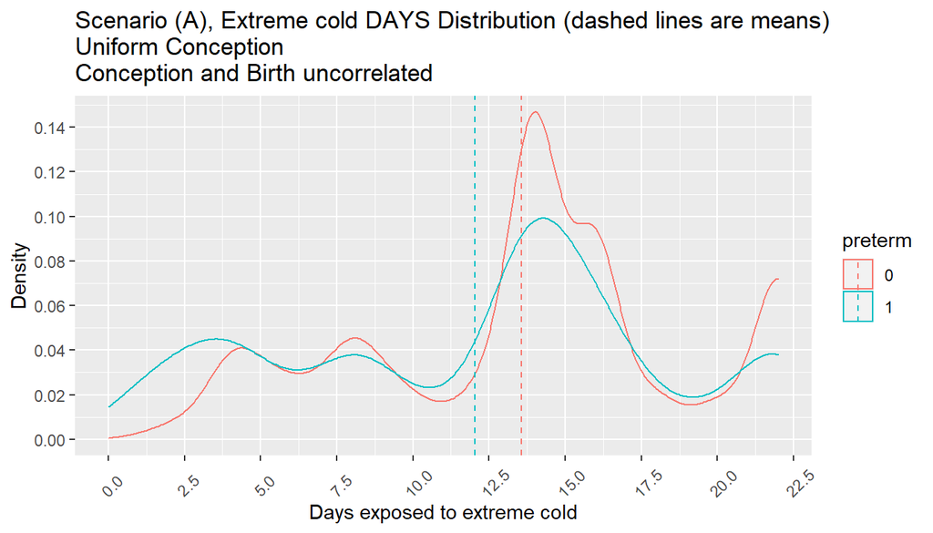

```r
# For tb_birth_cold_rand_cor0
st_title = paste0('Scenario (A), Extreme cold DAYS Distribution (dashed lines are means)\n',
                  'Uniform Conception\n',
                  'Conception and Birth uncorrelated')
ls_coldexp_preterm <- ffi_cold_days_preterm_analyze(tb_birth_cold_rand_cor0, st_title)
print(ls_coldexp_preterm$plt_temp_preterm)
```

### 1.7.3 Scenario B.1, number of days and preterm

Scenario B.1, number of days exposed to extreme cold distribution:

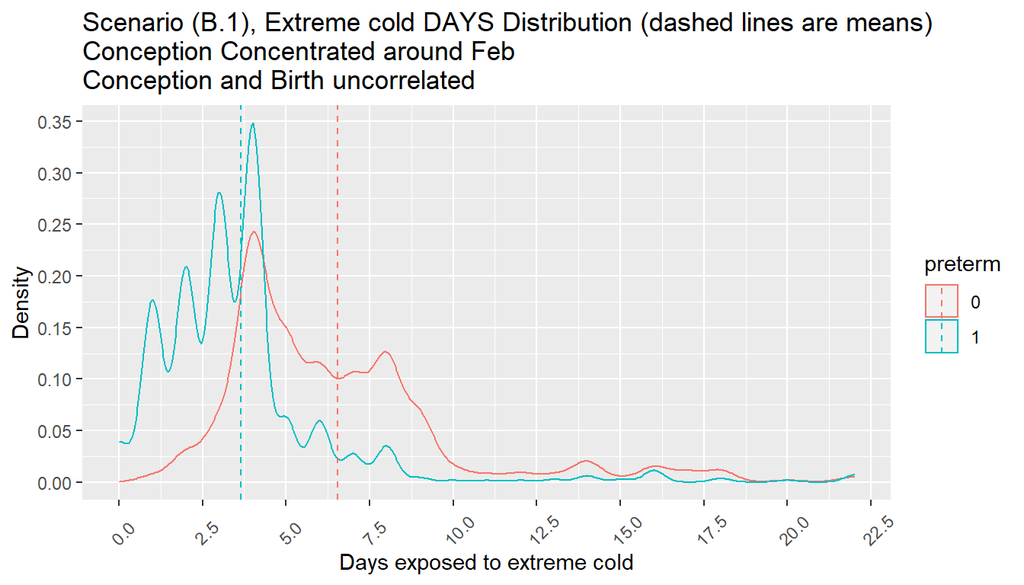

```r
# For tb_birth_cold_CFeb_cor0
st_title = paste0('Scenario (B.1), Extreme cold DAYS Distribution (dashed lines are means)\n',
                  'Conception Concentrated around Feb\n',
                  'Conception and Birth uncorrelated')
ls_coldexp_preterm <- ffi_cold_days_preterm_analyze(tb_birth_cold_CFeb_cor0, st_title)
print(ls_coldexp_preterm$plt_temp_preterm)
```

### 1.7.4 Scenario B.2, number of days and preterm

Scenario B.2, number of days exposed to extreme cold distribution (average lines largely overlap):

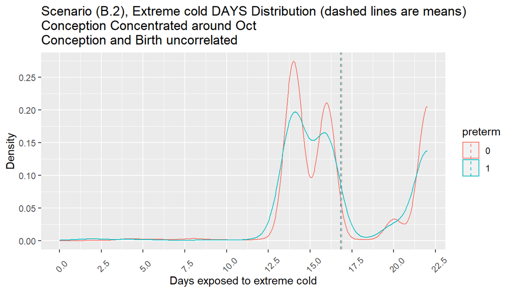

```r
# For tb_birth_cold_COct_cor0
st_title = paste0('Scenario (B.2), Extreme cold DAYS Distribution (dashed lines are means)\n',
                  'Conception Concentrated around Oct\n',
                  'Conception and Birth uncorrelated')
ls_coldexp_preterm <- ffi_cold_days_preterm_analyze(tb_birth_cold_COct_cor0, st_title)
print(ls_coldexp_preterm$plt_temp_preterm)
```

### 1.7.5 Scenario B.3, number of days and preterm

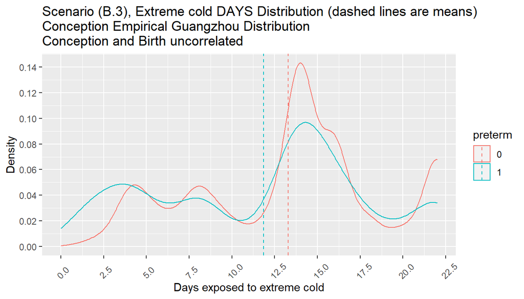

```r
# For tb_birth_cold_Clbhwz_cor0
st_title = paste0('Scenario (B.3), Extreme cold DAYS Distribution (dashed lines are means)\n',
                  'Conception Empirical Guangzhou Distribution\n',
                  'Conception and Birth uncorrelated')
ls_coldexp_preterm <- ffi_cold_days_preterm_analyze(tb_birth_cold_Clbhwz_cor0, st_title)
print(ls_coldexp_preterm$plt_temp_preterm)
```

### 1.7.6 Scenario A, percent of days and preterm

Scenario A, percent of days exposed to extreme cold distribution:

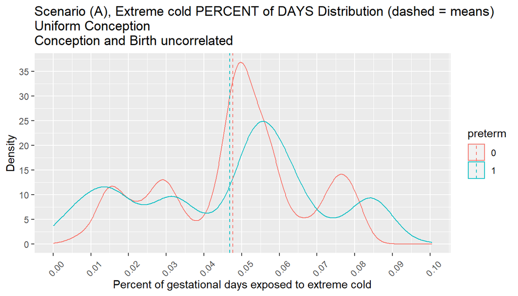

```r
# For tb_birth_cold_rand_cor0
st_title = paste0('Scenario (A), Extreme cold PERCENT of DAYS Distribution (dashed = means)\n',
                  'Uniform Conception\n',
                  'Conception and Birth uncorrelated')
ls_coldexp_preterm <- ffi_cold_percent_days_preterm_analyze(tb_birth_cold_rand_cor0, st_title)
print(ls_coldexp_preterm$plt_temp_preterm)
```

### 1.7.7 Scenario B.1, percent of days and preterm

Scenario B.1, percent of days exposed to extreme cold distribution:

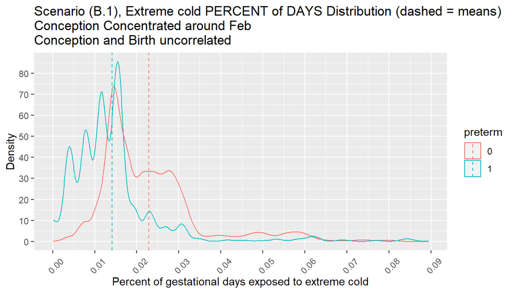

```r
# For tb_birth_cold_CFeb_cor0
st_title = paste0('Scenario (B.1), Extreme cold PERCENT of DAYS Distribution (dashed = means)\n',
                  'Conception Concentrated around Feb\n',
                  'Conception and Birth uncorrelated')
ls_coldexp_preterm <- ffi_cold_percent_days_preterm_analyze(tb_birth_cold_CFeb_cor0, st_title)
print(ls_coldexp_preterm$plt_temp_preterm)
```

### 1.7.8 Scenario B.2, percent of days and preterm

Fourth, Scenario B.2, percent of days exposed to extreme cold distribution:

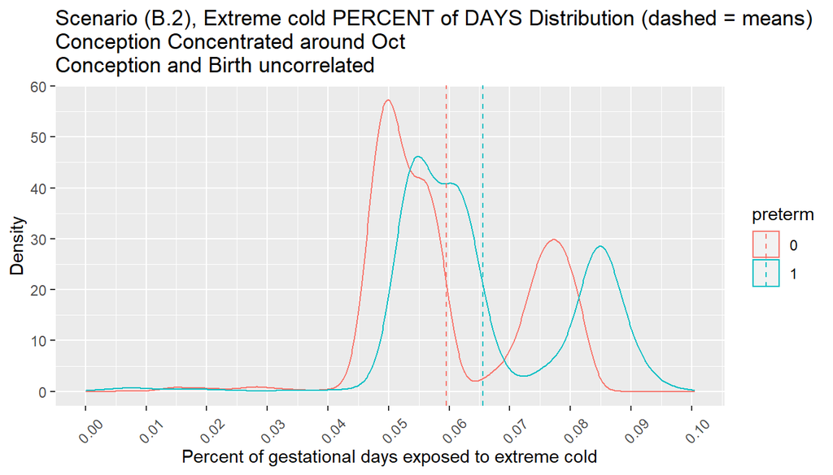

```r
# For tb_birth_cold_COct_cor0
st_title = paste0('Scenario (B.2), Extreme cold PERCENT of DAYS Distribution (dashed = means)\n',
                  'Conception Concentrated around Oct\n',
                  'Conception and Birth uncorrelated')
ls_coldexp_preterm <- ffi_cold_percent_days_preterm_analyze(tb_birth_cold_COct_cor0, st_title)
print(ls_coldexp_preterm$plt_temp_preterm)
```

### 1.7.9 Scenario B.3, percent of days and preterm

Scenario B.3, percent of days exposed to extreme cold distribution (average lines largely overlap), note this is the result based on the empirical conception distribution from Guangzhou:

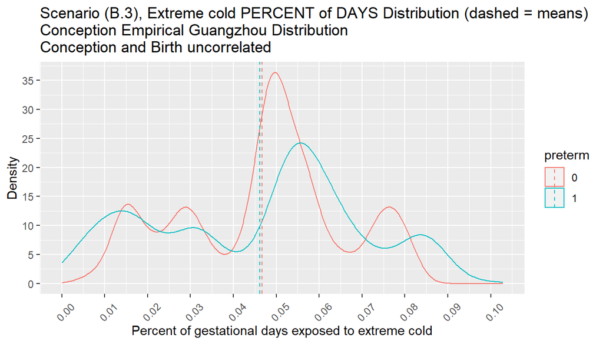

```r
# For tb_birth_cold_Clbhwz_cor0
st_title = paste0('Scenario (B.3), Extreme cold PERCENT of DAYS Distribution (dashed = means)\n',
                  'Conception Empirical Guangzhou Distribution\n',
                  'Conception and Birth uncorrelated')
ls_coldexp_preterm <- ffi_cold_percent_days_preterm_analyze(tb_birth_cold_Clbhwz_cor0, st_title)
print(ls_coldexp_preterm$plt_temp_preterm)
```